# CP1

Brian Liswell

12/2/2020

## Repro Course Project 1

### Commit containing full submission

### 1. Code for reading in the dataset and/or processing the data

```r
data <- read.csv('activity.csv')
summary(data)
```

```
##      steps                date          interval
##  Min.   :  0.00   2012-10-01:  288   Min.   :   0.0
##  1st Qu.:  0.00   2012-10-02:  288   1st Qu.: 588.8
##  Median :  0.00   2012-10-03:  288   Median :1177.5
##  Mean   : 37.38   2012-10-04:  288   Mean   :1177.5
##  3rd Qu.: 12.00   2012-10-05:  288   3rd Qu.:1766.2
##  Max.   :806.00   2012-10-06:  288   Max.   :2355.0
##  NA's   :2304     (Other)   :15840
```

### 2. Histogram of the total number of steps taken each day

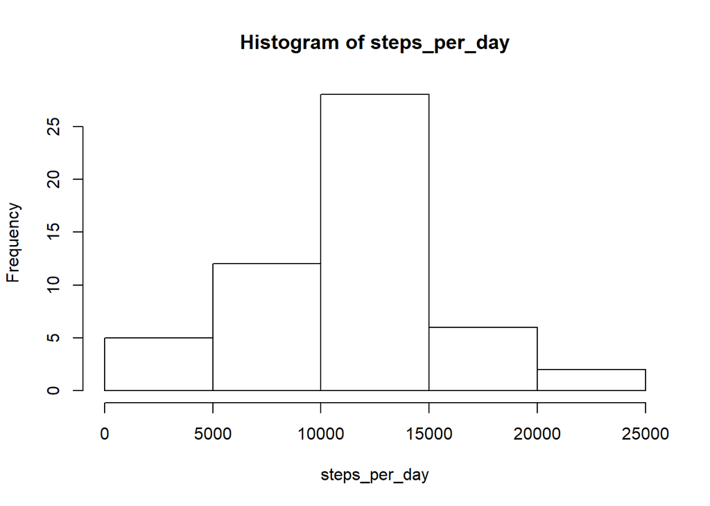

```r
data_by_date <- split(data,data$date)

date_names <- names(data_by_date)

steps_per_day <-numeric(length(date_names))
for(i in 1:length(steps_per_day)){  #length(steps_per_day)
        temp<-data_by_date[[date_names[i]]]$steps
        steps_per_day[i] <- sum(temp)

}
hist(steps_per_day)
```

### 3. Mean and median number of steps taken each day

```r
mean(steps_per_day,na.rm = TRUE)
```

```
## [1] 10766.19
```

```r
median(steps_per_day,na.rm = TRUE)
```

```
## [1] 10765
```

### 4. Time series plot of the average number of steps taken.

I think this means the total number of steps taken per day. Otherwise, over what time period is the “average”

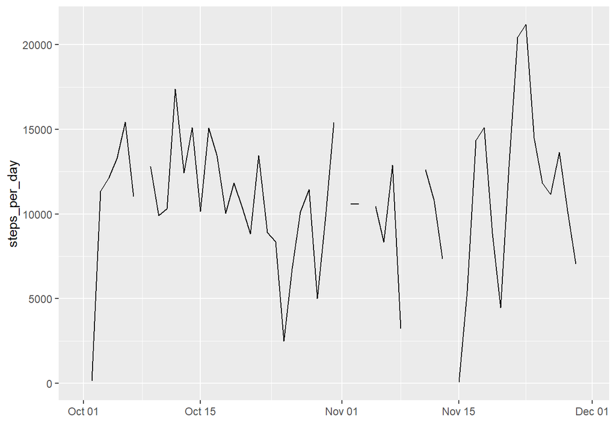

```r
library(ggplot2)

data_total <-data.frame(day = as.Date(date_names),value = steps_per_day)

p2 <- ggplot(data_total, aes(x = day, y = steps_per_day)) +
        geom_line() +
        xlab("")
p2
```

### OR

4. means to average accross all the 5 minute intervals from each day, which could be how to interpret number 5.

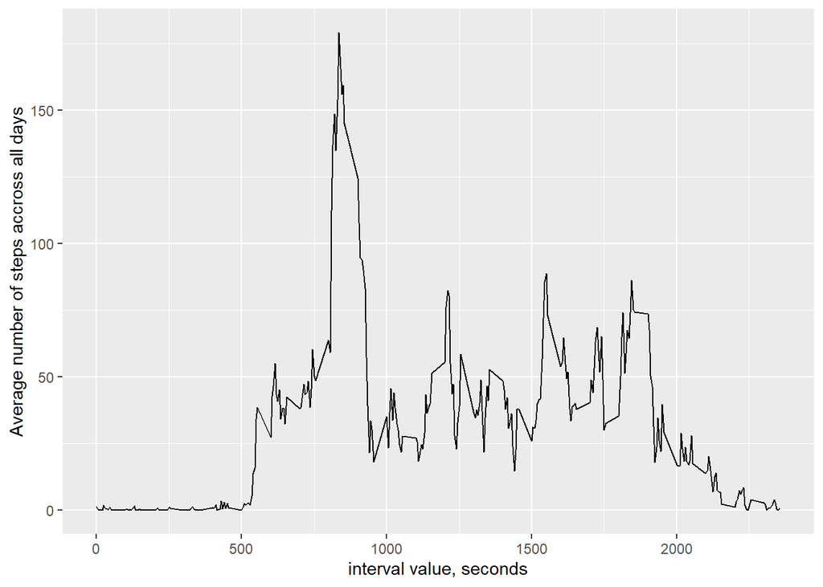

```r
steps_per_5min <-numeric(length(data_by_date[[date_names[1]]]$steps))
interval <- data_by_date[[date_names[1]]]$interval
cnt <-0
for(i in 1:length(date_names)){  #length(steps_per_day)
        temp<-data_by_date[[date_names[i]]]$steps
        temp[is.na(temp)] <-0
        steps_per_5min <- steps_per_5min + temp
        cnt <- cnt+1
}
avg_per_5min <- steps_per_5min/cnt
interval_avg <-data.frame(interval = interval,value = avg_per_5min)

p3 <- ggplot(interval_avg, aes(x = interval, y = value)) +
        geom_line() +
        xlab("interval value, seconds")+
        ylab("Average number of steps accross all days")
p3
```

### 5. The 5-minute interval that, on average, contains the maximum number of steps

```r
max_ind <- which.max(steps_per_5min)
print(paste0("interval number ",max_ind))
```

```
## [1] "interval number 104"
```

```r
print(paste0("At this many seconds into the day ",interval[max_ind]))
```

```
## [1] "At this many seconds into the day 835"
```

### 6. Code to describe and show a strategy for imputing missing data

I did this above in step 4, with temp[is.na(temp)] <-0, which replaces the missing data with 0. I did not do this for the code in step 2. See the effects in step 7.

### 7. Histogram of the total number of steps taken each day after missing values are imputed

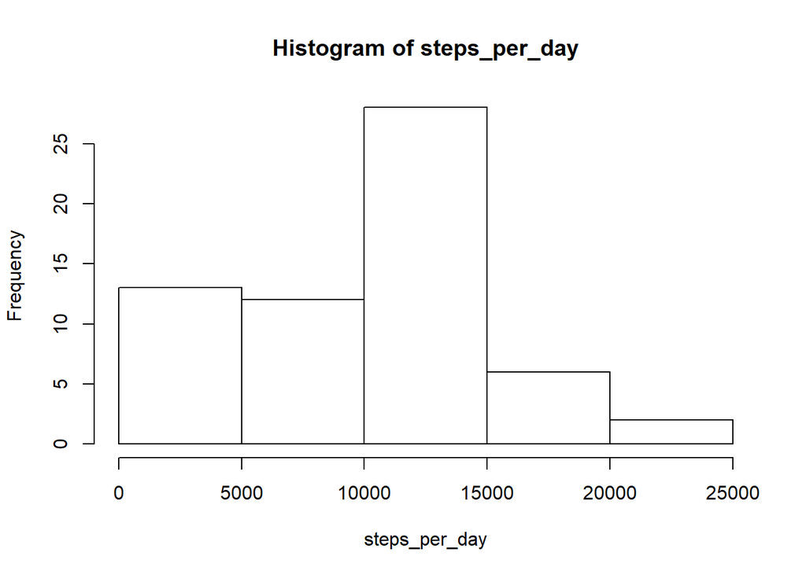

```r
data_by_date <- split(data,data$date)

date_names <- names(data_by_date)

steps_per_day <-numeric(length(date_names))
for(i in 1:length(steps_per_day)){  #length(steps_per_day)
        temp<-data_by_date[[date_names[i]]]$steps
        temp[is.na(temp)] <-0
        steps_per_day[i] <- sum(temp)

}
hist(steps_per_day)
```

### 8. Panel plot comparing the average number of steps taken per 5-minute interval across weekdays and weekends

“What is a Week ‘end’?”

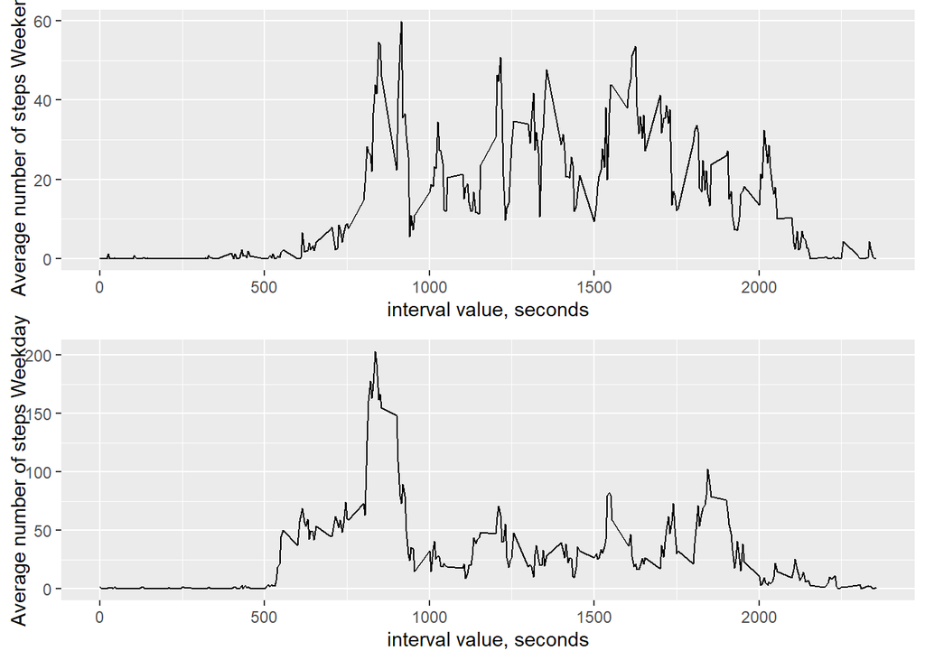

```r
date_names_Date <- as.Date(date_names)
library(timeDate)



wd_steps_per_5min <-numeric(length(data_by_date[[date_names[1]]]$steps))
we_steps_per_5min <-numeric(length(data_by_date[[date_names[1]]]$steps))
interval <- data_by_date[[date_names[1]]]$interval
wd_cnt <-0
we_cnt <-0

for(i in 1:length(date_names)){  #length(steps_per_day)
        temp<-data_by_date[[date_names[i]]]$steps
        temp[is.na(temp)] <-0

        if(isWeekday(date_names_Date[i], wday=1:5)){
                wd_steps_per_5min <- wd_steps_per_5min + temp
                wd_cnt <- wd_cnt+1

        }
        else{
                we_steps_per_5min <- we_steps_per_5min + temp
                we_cnt <- wd_cnt+1
        }
}
wd_avg_per_5min <- wd_steps_per_5min/wd_cnt
we_avg_per_5min <- we_steps_per_5min/we_cnt
compare_avg <-data.frame(interval = interval,wd = wd_avg_per_5min,we = we_avg_per_5min)
we_avg <-data.frame(interval = interval,value = we_avg_per_5min)
wd_avg <-data.frame(interval = interval,value = wd_avg_per_5min)

p_we <- ggplot(we_avg, aes(x = interval, y = value)) +
        geom_line() +
        xlab("interval value, seconds")+
        ylab("Average number of steps Weekend")

p_wd <- ggplot(wd_avg, aes(x = interval, y = value)) +
        geom_line() +
        xlab("interval value, seconds")+
        ylab("Average number of steps Weekday")

library(grid)
library(gtable)
g_we_avg <- ggplotGrob(p_we)
g_wd_avg <- ggplotGrob(p_wd)
g <- rbind(g_we_avg,g_wd_avg,size = "first")

grid.newpage()
grid.draw(g)
```

### 9. All of the R code needed to reproduce the results (numbers, plots, etc.) in the report

I believe this file, CP1.Rmd, satisfies this